# 5주차: 범주형 자료와 분할표

Li et al., BMC Public Health 2023;23:1122 재현 (NHANES 2009-2018)

## 2. 검증 과제

### ① Fisher 정확검정의 실제 유의수준

두 독립 이항(그룹당 n, 공통 확률 π)에서 귀무가설이 참일 때 기각 확률을 계산했다. Fisher p 값은 π와 무관하게 (x₁, x₂)만으로 정해진다. 그래서 n마다 기각역을 한 번 구한 뒤, π마다 이항 확률을 더해 **정확한** 크기를 얻었다. 몬테카를로(B = 10,000, 99% 구간)는 이 계산을 교차 확인하는 용도로만 썼고, 72 / 72 조건이 통과했다(거짓 실패 기대치 0.72).

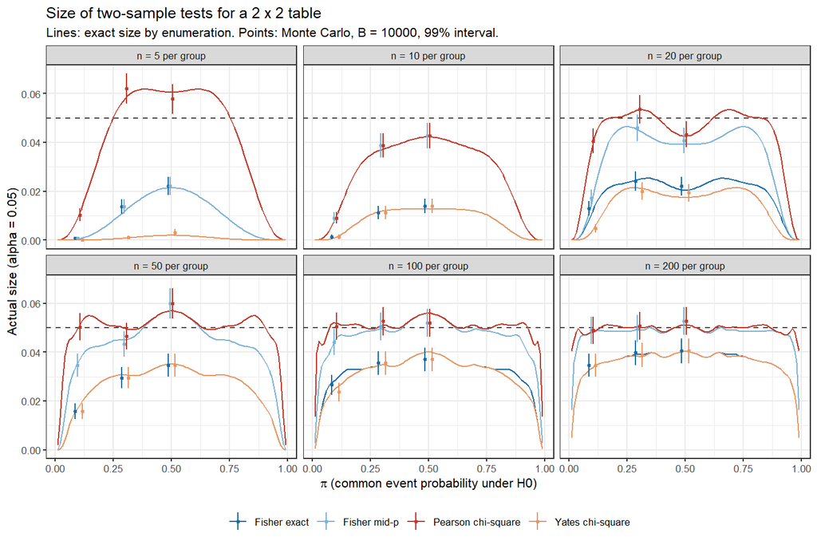

π 격자(0.01-0.99)에서의 최대 실제 크기 (명목 0.05)

[output not shown]

Fisher와 Yates는 모든 조건에서 0.05 아래였고, 대체로 크게 아래였다. Pearson은 작은 n에서 0.05를 넘었다(n = 5에서 최대 0.062). mid-p는 명목 수준에 가장 가까웠다. 검정통계량이 이산적이어서 명목 α를 정확히 맞출 수 없기 때문이며, 보수적인 쪽(Fisher)과 자유로운 쪽(Pearson)으로 갈린다. 이 논문처럼 칸 빈도가 수백~수천이면 차이가 사라지므로, 논문이 χ² 검정을 쓴 것 자체는 문제가 아니다.

### ② 유병률이 높을 때 OR이 RR을 과장하는 정도

표 2·3의 모든 대비에 대해, 같은 공변량으로 로지스틱 OR과 수정 포아송(log link) RR을 추정했다. 기준군 유병률 P₀는 대비마다 그 기준군에서 따로 구했다.

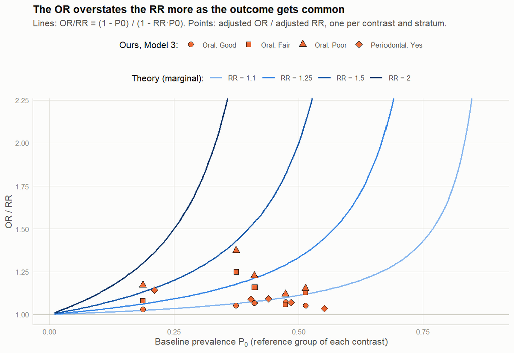

Model 3, 가장 강한 대비 (가중, 95% CI)

| 층 | 노출 | P0 | OR | RR | OR/RR | Zhang-Yu RR |
| --- | --- | --- | --- | --- | --- | --- |
| 전체 | 구강건강 Poor | 0.412 | 1.48 (1.24-1.76) | 1.21 (1.13-1.29) | 1.226 | 1.236 |
| 전체 | 치주질환 | 0.439 | 1.23 (1.11-1.36) | 1.12 (1.08-1.17) | 1.092 | 1.116 |
| 비흡연 | 구강건강 Poor | 0.375 | 1.68 (1.32-2.15) | 1.23 (1.12-1.34) | 1.374 | 1.341 |
| 비흡연 | 치주질환 | 0.405 | 1.22 (1.02-1.46) | 1.12 (1.04-1.21) | 1.090 | 1.120 |
| 흡연 | 구강건강 Poor | 0.473 | 1.27 (1.02-1.59) | 1.14 (1.04-1.24) | 1.120 | 1.128 |
| 흡연 | 치주질환 | 0.485 | 1.18 (1.00-1.38) | 1.10 (1.03-1.17) | 1.068 | 1.083 |
| 연령 < 45 | 구강건강 Poor | 0.187 | 1.61 (1.20-2.15) | 1.37 (1.14-1.65) | 1.171 | 1.443 |
| 연령 < 45 | 치주질환 | 0.210 | 1.46 (1.21-1.76) | 1.28 (1.14-1.44) | 1.141 | 1.331 |
| 연령 ≥ 45 | 구강건강 Poor | 0.514 | 1.25 (1.03-1.51) | 1.08 (1.02-1.16) | 1.152 | 1.107 |
| 연령 ≥ 45 | 치주질환 | 0.552 | 1.05 (0.93-1.20) | 1.02 (0.97-1.07) | 1.035 | 1.023 |

과장 정도는 P₀가 클수록 커진다. 다만 P₀만으로 정해지지는 않고 효과 크기와 함께 결정된다. 예를 들어 연령 ≥ 45 Poor(P₀ = 0.51)보다 비흡연 Poor(P₀ = 0.38)의 OR/RR이 더 크다. 보정된 OR을 Zhang-Yu 공식으로 RR로 바꾸면 직접 추정한 RR보다 대개 크게 나온다. 이 공식은 보정(조건부) OR을 주변 OR처럼 다루기 때문이다.

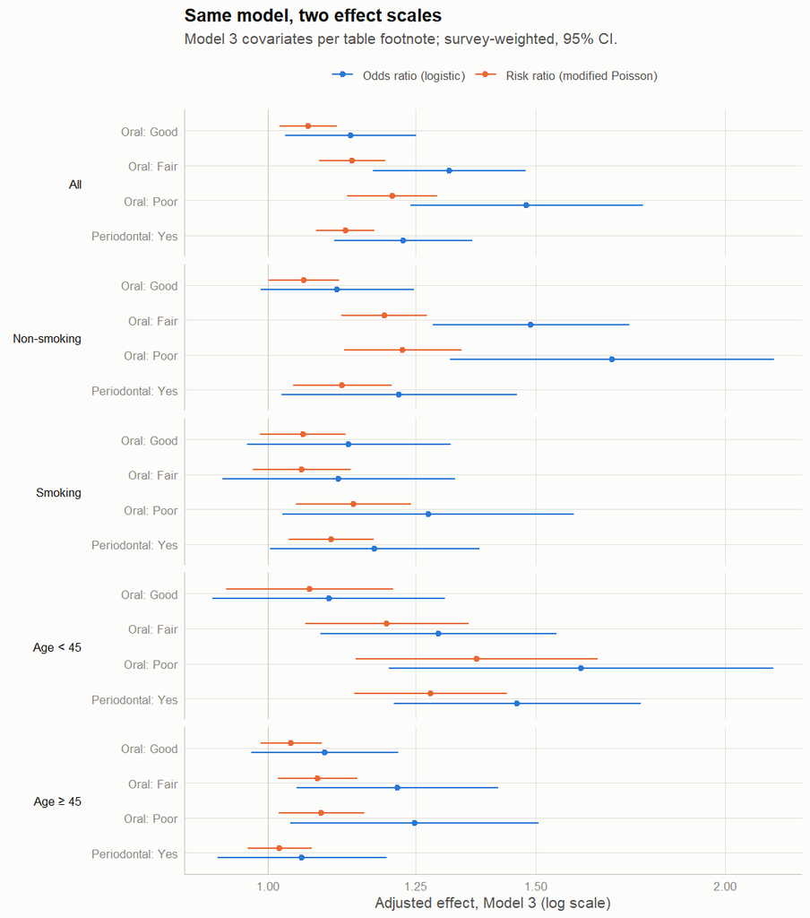

**비붕괴성.** 노출과 독립인 공변량, 즉 교란이 아닌 변수도 결과를 강하게 예측하면 OR을 움직인다. 정확 계산에서 조건부 OR이 2일 때, 그 공변량을 무시한 주변 OR은 효과가 커질수록 1.52까지 내려갔다. 반면 log-linear 모형의 주변 RR은 모든 경우에 정확히 1.5였다. 따라서 “보정 후 OR이 변했다 = 교란이 있었다”는 해석은 OR에서는 성립하지 않을 수 있다. 실제로 이 자료에서 Model 1 → 3으로 갈 때 OR의 변화는 RR의 변화보다 일관되게 컸다(전체 Poor: OR -0.335, RR -0.119).

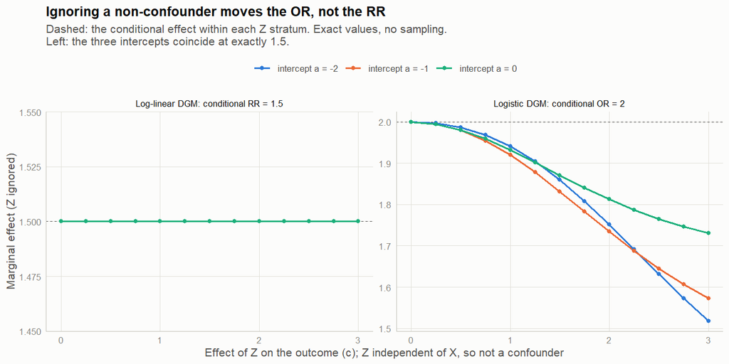

## 3. 자료

NHANES 2009-2018(F-J 5주기), 30세 이상이다. 혈압은 청진식 BPX만 썼고(2017-18의 오실로메트릭 BPXO는 쓰지 않음), 확장기 혈압 0은 평균을 내기 전에 결측으로 바꿨다. 가중치는 WTMEC2YR/5이며, 설계 객체는 전체 49,693명으로 만든 뒤 `subset()`으로 분석 영역을 잡았다.

제외 과정 (v2 = 감사 후 수정, 6절)

| 단계 | v1 제외 | v2 제외 | v2 남음 | 논문 |
| --- | --- | --- | --- | --- |
| 30세 이상 | 25,651 | 25,651 | 24,042 |  |
| 혈압 없음 제외 | 1,945 | 1,879 | 22,163 | 19,398 |
| 흡연·구강건강·치주 결측 제외 | 680 | 687 | 21,476 | 1,090 |
| 최종 |  |  | 21,476 | 21,800 |

논문의 제외 인원 19,398 + 1,090에 최종 21,800을 더하면 42,288인데, 2009-2018년의 30세 이상 인원과 맞지 않는다(A1). 분석 전에 pointblank로 표본 규칙을 검사했다. 필수 규칙 22개가 모두 통과했고, 경고 3개는 예상된 것이었다(N, 증례 수, 고혈압 미상 18명). 데이터를 일부러 망가뜨린 변이 8종도 모두 해당 규칙에서 멈춰, 규칙이 실제로 작동함을 확인했다.

## 4. 표 1: 분할표와 Rao-Scott 보정

가중 열 % (일부 변수)

| 변수 | 수준 | 우리 % (비고혈압 / 고혈압) | 논문 % |
| --- | --- | --- | --- |
| Smoking | Yes | 41.99 / 49.84 | 42.01 / 49.76 |
| Smoking | No | 58.01 / 50.16 | 57.99 / 50.24 |
| Periodontal | Yes | 16.54 / 19.94 | 16.47 / 19.92 |
| Periodontal | No | 83.46 / 80.06 | 83.53 / 80.08 |
| Oral | Excellent/Very good | 40.83 / 35.02 | 40.87 / 34.83 |
| Oral | Good | 33.97 / 33.90 | 34.00 / 34.00 |
| Oral | Fair | 17.59 / 19.88 | 17.53 / 19.91 |
| Oral | Poor | 7.61 / 11.20 | 7.60 / 11.27 |
| Sleep | <7 | 29.57 / 31.50 | 68.23 / 67.52 |
| Sleep | 7-9 | 66.61 / 61.11 | 28.93 / 27.53 |
| Sleep | >9 | 3.62 / 6.86 | 2.84 / 4.95 |
| Sleep | Missing | 0.20 / 0.53 |  |
| Alcohol | No drinks | 21.88 / 29.93 | 3.07 / 4.87 |
| Alcohol | <=1 drink/week | 45.25 / 39.77 | 45.21 / 39.46 |
| Alcohol | >1 drink/week | 25.16 / 24.20 | 25.24 / 23.82 |
| Alcohol | Missing | 7.71 / 6.10 | 26.48 / 31.84 |

연속형 (비고혈압 / 고혈압). 중성지방은 LBXSTR이 논문 값과 맞는다

| 변수 | 가중치·변수 | 우리 평균 (SE) | 논문 |
| --- | --- | --- | --- |
| Age | WTMEC2YR/5 | 47.90 (0.23) / 59.12 (0.21) | 47.95 (0.24) / 59.04 (0.21) |
| Triglyceride | WTMEC2YR/5 | 146.72 (1.88) / 172.47 (1.98) | 146.27 (1.85) / 172.62 (1.90) |
| HbA1c | WTMEC2YR/5 | 5.55 (0.01) / 5.98 (0.01) | 5.55 (0.01) / 5.98 (0.01) |
| Triglyceride | WTMEC2YR/5 (fasting LBXTR) | 115.36 (1.57) / 139.05 (2.71) | 146.27 (1.85) / 172.62 (1.90) |
| Triglyceride | WTSAF2YR/5 (fasting LBXTR) | 114.92 (1.60) / 137.78 (2.45) | 146.27 (1.85) / 172.62 (1.90) |

χ² 검정 네 가지

| 변수 | 방법 | 통계량 | 자유도 | p | 논문 p |
| --- | --- | --- | --- | --- | --- |
| Sex | naive_weighted | 102300.58 | 1 | 0.0e+00 | 0.015 |
| Sex | rao_scott_1 | 12.50 | 1 | 0.005 | 0.015 |
| Sex | rao_scott_2 | 7.90 | 1, 78 | 0.006 | 0.015 |
| Sex | unweighted | 6.87 | 1 | 0.009 | 0.015 |
| Periodontal | naive_weighted | 339977.08 | 1 | 0.0e+00 | <0.001 |
| Periodontal | rao_scott_1 | 41.54 | 1 | 2.2e-07 | <0.001 |
| Periodontal | rao_scott_2 | 26.89 | 1, 78 | 1.7e-06 | <0.001 |
| Periodontal | unweighted | 15.08 | 1 | 1.0e-04 | <0.001 |
| Oral | naive_weighted | 1113811.67 | 3 | 0.0e+00 | <0.001 |
| Oral | rao_scott_1 | 136.08 | 3 | 1.1e-17 | <0.001 |
| Oral | rao_scott_2 | 27.38 | 2.92, 227.58 | 7.3e-15 | <0.001 |
| Oral | unweighted | 99.86 | 3 | 1.7e-21 | <0.001 |

가중 빈도를 그대로 `chisq.test`에 넣으면 표본 크기가 모집단 크기(약 1억 7,500만 명)로 계산되어, 통계량이 수십만이 되고 p는 0이 된다. Rao-Scott 보정은 이 통계량을 설계효과로 나눠 표본 설계에 맞는 크기로 되돌린다. 1차 보정은 SAS `PROC SURVEYFREQ`의 기본값이고 R `svychisq(statistic = "Chisq")`에 해당한다. 논문에서 유일하게 0.001보다 큰 성별 p(0.015)는 어느 방법으로도 재현되지 않았다(1차 보정 0.005). 표본 자체가 달라서 어느 방법을 썼는지 판별할 수 없다.

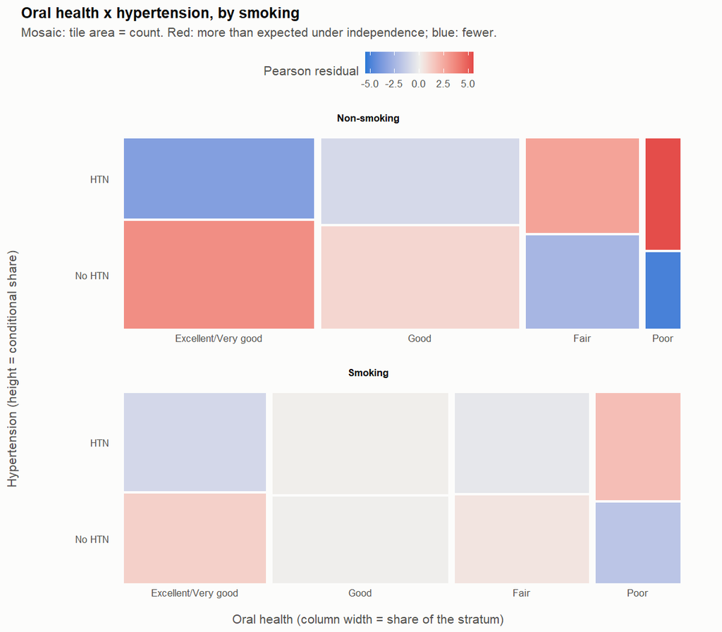

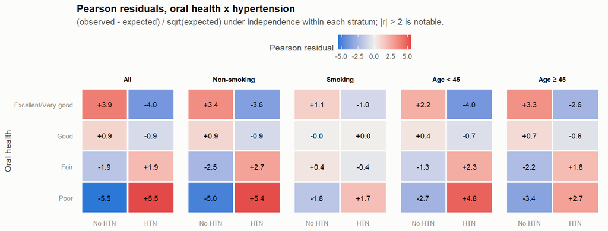

Pearson 잔차를 보면 Poor × 고혈압 칸이 비흡연층에서는 +5.4, 흡연층에서는 +1.7다. 연관은 비흡연층에서 더 강하고, 이는 5절의 열 뒤바뀜 결론과 같은 방향이다.

## 5. 표 2·3: 보정 오즈비

`svyglm(quasibinomial)`로 표 각주의 Model 1-3을 그대로 적합했다. 표 2 Model 2·3에는 CVD, 당뇨, 나트륨, 지방, 검사값이 들어가고, 표 3 Model 1에는 나이가 없다. 결측 공변량은 범주형이면 Missing 범주로, 연속형이면 평균 대치와 지시변수로 처리했다.

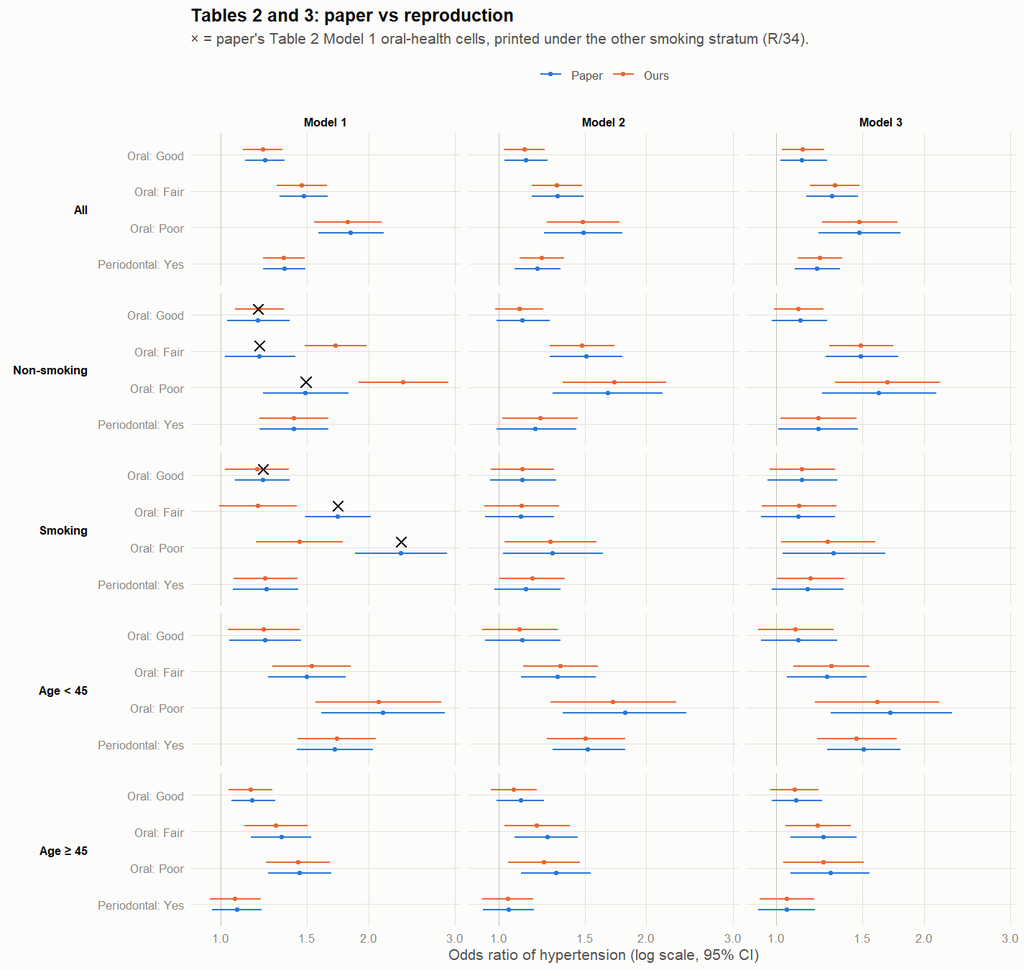

표 2 구강건강 Model 1: 층 뒤바뀜 검정

| 수준 | 우리 비흡연 | 우리 흡연 | 논문 비흡연 | 논문 흡연 | \|차이\| 합, 같은 층 | \|차이\| 합, 층 바꿈 |
| --- | --- | --- | --- | --- | --- | --- |
| Good | 1.20 | 1.19 | 1.19 | 1.22 | 0.04 | 0.02 |
| Fair | 1.71 | 1.19 | 1.20 | 1.73 | 1.05 | 0.02 |
| Poor | 2.36 | 1.45 | 1.49 | 2.33 | 1.75 | 0.07 |

이 패턴은 논문 자체에서도 확인된다. 논문의 증례/전체 수로 계산한 조 OR은 비흡연층(Poor 1.88)이 흡연층(1.22)보다 크다. 그런데 인쇄된 Model 1에서는 반대다. 반면 같은 표의 Model 2·3, 치주질환, 증례/전체 수는 뒤바뀌지 않았다.

**P-trend.** 비흡연층 구강건강 Model 3의 논문 값 0.032는, 논문 자신의 CI로부터 역산한 Fair p(4×10⁻⁶)·Poor p(4×10⁻⁴)와 양립하지 않는다(A14). 우리 값은 3.3e-07다. 치주질환의 P-trend 12개는 모두 CI에서 역산한 Wald p와 일치했으므로, 논문의 이분형 P-trend는 Wald p다(A7).

P-interaction (곱셈항 Wald 검정)

| 표 | 교호작용 | 모형 | F | 자유도 | p | 논문 |
| --- | --- | --- | --- | --- | --- | --- |
| Table 2 | oral × smoke | 1 | 7.42 | 3, 62 | 2.5e-04 | <0.001 |
| Table 2 | oral × smoke | 2 | 3.35 | 3, 44 | 0.027 | <0.001 |
| Table 2 | oral × smoke | 3 | 3.51 | 3, 35 | 0.025 | <0.001 |
| Table 2 | perio × smoke | 1 | 1.24 | 1, 66 | 0.270 | <0.001 |
| Table 2 | perio × smoke | 2 | 0.13 | 1, 48 | 0.716 | <0.001 |
| Table 2 | perio × smoke | 3 | 0.16 | 1, 39 | 0.691 | <0.001 |
| Table 3 | oral × age_grp | 1 | 1.56 | 3, 63 | 0.209 | <0.001 |
| Table 3 | oral × age_grp | 2 | 1.66 | 3, 51 | 0.186 | <0.001 |
| Table 3 | oral × age_grp | 3 | 1.19 | 3, 42 | 0.324 | <0.001 |
| Table 3 | perio × age_grp | 1 | 18.23 | 1, 67 | 6.3e-05 | <0.001 |
| Table 3 | perio × age_grp | 2 | 13.78 | 1, 55 | 4.8e-04 | <0.001 |
| Table 3 | perio × age_grp | 3 | 10.96 | 1, 46 | 0.002 | <0.001 |

**흡연 보정(A13).** 방법 절에는 흡연이 보정 변수로 나오지만 표 2 각주에는 없다. 흡연을 추가하면 Model 3 Poor가 1.480에서 1.439로 줄어든다. 논문 값 1.48은 흡연을 뺀 각주 그대로의 모형과 맞는다.

**고혈압 정의 민감도.** 논문 주장대로, 구강건강 Poor는 측정 기준(1.46 (1.22-1.74))과 진단 기준(1.40 (1.17-1.69)) 모두에서 연관이 있었다. 치주질환은 진단 기준에서만 연관이 있었다(측정 0.94, 진단 1.34).

**McNemar.** 같은 사람을 두 정의로 판정한 짝지은 표에서 불일치 칸은 b = 1,632(혈압은 높지만 진단받은 적 없음), c = 5,794(진단·치료받았고 현재 혈압은 정상)이다. 비가중 McNemar χ² = 2332.6이지만, 설계 기반 짝 차이 검정의 t² 는 707.6이다. 표 1의 Rao-Scott와 같은 설계효과가 여기서도 나타난다.

## 6. 감사로 바뀐 것

결과를 ledger에 넣기 전에 ai-error-auditor가 코드를 독립 감사했다. DBP 측정값이 전부 0인 59명이 SBP가 있는데도 “혈압 없음”으로 빠진 것을 찾아냈고, `R/11_build_analytic_sample_v2.R`로 고쳤다(`CHANGES_v2.md`). 그 결과 N은 21,417에서 21,476으로, OR은 최대 0.006 바뀌었고 결론은 바뀌지 않았다. ledger의 허용 오차는 스킬 규칙(표시 자릿수의 반 단위)을 유지했다. 계획서 기준 ±0.03에 드는 OR 행은 evidence에 따로 표시했다.

## 7. ledger 현황

| 상태 | 행 수 |
| --- | --- |
| match | 111 |
| mismatch | 228 |
| not reproduced | 0 |
| open | 87 |

open 행의 위치

| 표 | 행 수 |
| --- | --- |
| Abstract | 4 |
| Table 1 | 33 |
| Table 1 (continued) | 15 |
| Table 2 | 11 |
| Table 3 | 12 |
| text p.5 | 12 |

open 행은 주로 정의를 알 수 없는 표 1 변수(수면, 신체활동, 당뇨, BMI 극단 범주, CVD 결측)와 P-interaction, 일부 P-trend다. 원인을 증명하지 못한 행은 고쳐 맞추거나 지우지 않고 그대로 남겼다.